# 05 Mejoras con datos meteorológicos horarios y geoespaciales

### 2.2 Construcción de la serie horaria AEMET limpia

```python
# Coordenadas WGS84 de las estaciones AEMET (fuente: catálogo AEMET)
AEMET_STATIONS = {
    "Barcelona_Aeropuerto": {"lat": 41.2971, "lon": 2.0785},
    "Barcelona_PortOlimpic": {"lat": 41.3874, "lon": 2.1970},
    "Barcelona_Drassanes":  {"lat": 41.3735, "lon": 2.1750},
}

# La fórmula haversine calcula la distancia en línea recta entre dos puntos sobre la superficie de la Tierra
# dadas sus coordenadas de latitud y longitud (WGS84).
def haversine_km(lat1, lon1, lat2, lon2):
    """Distancia en km entre dos puntos WGS84."""
    R = 6371
    dlat = radians(lat2 - lat1)
    dlon = radians(lon2 - lon1)
    a = sin(dlat/2)**2 + cos(radians(lat1)) * cos(radians(lat2)) * sin(dlon/2)**2
    return R * 2 * asin(sqrt(a))

# Pivotar a formato ancho: un registro por hora, columnas por estación
campos_utiles = ['temp_c', 'humedad_pct', 'precipitacion_mm', 'viento_vel_ms', 'viento_dir_grad']

# Forward fill por estación antes de pivotar (hasta 3h de hueco)
# Forward fill (relleno hacia adelante) es una técnica para cubrir valores nulos en una serie temporal propagando
# el último valor conocido hacia las filas siguientes.
# La lógica es: si el sensor falló a las 9h, lo más razonable es asumir que la temperatura era parecida a la de las 8h,
# no que era cero ni la media del día.
aemet_clean = []
for est, grp in df_aemet.groupby("estacion"):
    grp = grp.sort_values("fecha").copy()
    grp[campos_utiles] = grp[campos_utiles].ffill(limit=3)
    aemet_clean.append(grp)
df_aemet_clean = pd.concat(aemet_clean, ignore_index=True)

# Pivotamos: índice=fecha, columnas=estacion_campo
df_wide = df_aemet_clean.pivot_table(index="fecha", columns="estacion", values=campos_utiles)
df_wide.columns = [f"{campo}__{est}" for campo, est in df_wide.columns]
df_wide = df_wide.reset_index().rename(columns={"fecha": "hora"})

print(f"Serie horaria AEMET wide: {df_wide.shape}")
print("Columnas:", df_wide.columns.tolist()[:10], "...")
```

```
Serie horaria AEMET wide: (35064, 14)
Columnas: ['hora', 'humedad_pct__Barcelona_Aeropuerto', 'humedad_pct__Barcelona_Drassanes', 'humedad_pct__Barcelona_PortOlimpic', 'precipitacion_mm__Barcelona_Aeropuerto', 'precipitacion_mm__Barcelona_Drassanes', 'precipitacion_mm__Barcelona_PortOlimpic', 'temp_c__Barcelona_Aeropuerto', 'temp_c__Bar…
```

## 3. Características geoespaciales de los tramos

### 3.1 Distancias a lugares de eventos y puntos de referencia

```python
# Lugares de eventos relevantes en Barcelona
VENUES = {
    "camp_nou":        {"lat": 41.3809, "lon": 2.1228},
    "palau_sant_jordi":{"lat": 41.3640, "lon": 2.1530},
    "forum_barcelona": {"lat": 41.4106, "lon": 2.2197},
    "placa_catalunya": {"lat": 41.3870, "lon": 2.1700},
    "arc_triomf":      {"lat": 41.3910, "lon": 2.1800},
    "palau_musica":    {"lat": 41.3877, "lon": 2.1750},
}

# Extraer coordenadas únicas por tramo
geo_trams = (df_base[["idTram", "lat_centre", "lon_centre"]]
             .drop_duplicates("idTram")
             .copy())

# Distancias a cada evento
for name, coords in VENUES.items():
    geo_trams[f"dist_{name}_km"] = geo_trams.apply(
        lambda r: haversine_km(r.lat_centre, r.lon_centre, coords["lat"], coords["lon"]),
        axis=1
    )

# Distancias a cada estación AEMET
for est_name, est_coords in AEMET_STATIONS.items():
    col = "dist_aemet_" + est_name.replace("Barcelona_", "").lower() + "_km"
    geo_trams[col] = geo_trams.apply(
        lambda r: haversine_km(r.lat_centre, r.lon_centre, est_coords["lat"], est_coords["lon"]),
        axis=1
    )

# Venue más cercano por tramo
dist_venue_cols = [f"dist_{n}_km" for n in VENUES]
geo_trams["venue_cercano"] = geo_trams[dist_venue_cols].idxmin(axis=1).str.replace("dist_", "").str.replace("_km", "")
geo_trams["dist_venue_min_km"] = geo_trams[dist_venue_cols].min(axis=1)

print(geo_trams[["idTram"] + dist_venue_cols + ["venue_cercano","dist_venue_min_km"]].to_string())
print(f"\nVenue más frecuente como vecino: {geo_trams['venue_cercano'].value_counts().to_dict()}")
```

```
         idTram  dist_camp_nou_km  dist_palau_sant_jordi_km  dist_forum_barcelona_km  dist_placa_catalunya_km  dist_arc_triomf_km  dist_palau_musica_km    venue_cercano  dist_venue_min_km
0             1          1.356050                  4.393527                 9.910269                 5.294775            6.175165              5.717179         camp_nou           1.356050
24127         2          1.361026                  4.407221                 9.901426                 5.292384            6.171056              5.714574         camp_nou           1.361026
42487         3          0.689792                  3.820400                 8.977319                 4.393429            5.259344              4.813473         camp_nou           0.689792
69320         4          0.715424                  3.843447                 8.976127                 4.400117            5.263831              4.819793         camp_nou           0.715424
96161         5          0.765252                  3.504208                 8.295345                 3.745575            4.595107              4.162187         camp_nou           0.765252
122751        6          0.790076                  3.529401                 8.293669                 3.753211            4.599970              4.169257         camp_nou           0.790076
147921        7          1.071458                  3.355076                 7.854229                 3.332632            4.167719              3.745668         camp_nou           1.071458
173656       10          1.912144                  3.254264                 6.923597                 2.509715            3.288797              2.905747         camp_nou           1.912144
199506       11          1.314536                  4.435656                 9.685652                 5.139675            6.000533              5.559159         camp_nou           1.314536
218693       12          1.556824                  4.693903                 9.487137                 5.089236            5.909002              5.500321         camp_nou           1.556824
245665       13          1.564660                  4.701859                 9.493029                 5.096542            5.915988              5.507558         camp_nou           1.564660
269467       15          1.875220                  4.743756                 8.658625                 4.532825            5.266943              4.920124         camp_nou           1.875220
286406       16          1.331772                  4.367736                 8.911651                 4.545538            5.350131              4.952520         camp_nou           1.331772
309532       17          1.335281                  4.370410                 8.910524                 4.545806            5.349997              4.952688         camp_nou           1.335281
```

[output cut: 44 more lines]

### 3.2 Mapa de calor: distancia de tramos al Camp Nou

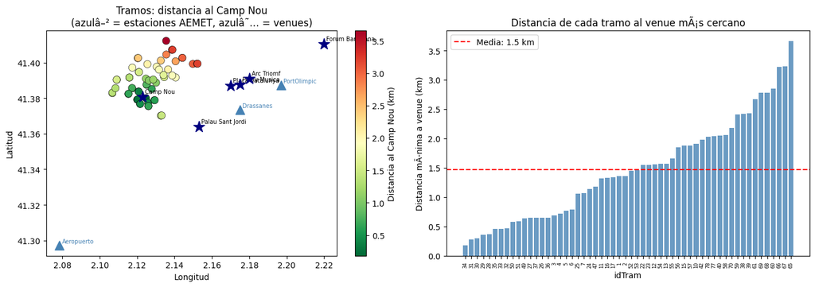

```
Fig. 1: PosiciÃ³n geogrÃ¡fica de tramos coloreados por distancia al Camp Nou.
```

```python
fig, axes = plt.subplots(1, 2, figsize=(14, 5))

# Panel 1: Posición de tramos y venues
ax = axes[0]
sc = ax.scatter(geo_trams.lon_centre, geo_trams.lat_centre,
                c=geo_trams.dist_camp_nou_km, cmap="RdYlGn_r",
                s=80, zorder=3, edgecolors="k", linewidths=0.4)
plt.colorbar(sc, ax=ax, label="Distancia al Camp Nou (km)")
# Marcar venues
venue_coords = list(VENUES.items())
for name, vc in venue_coords:
    ax.scatter(vc["lon"], vc["lat"], marker="*", s=200, color="navy", zorder=5)
    ax.annotate(name.replace("_", " ").title(), (vc["lon"], vc["lat"]),
                fontsize=7, ha="left", va="bottom",
                xytext=(3, 3), textcoords="offset points")
# Marcar estaciones AEMET
for est, sc_coords in AEMET_STATIONS.items():
    ax.scatter(sc_coords["lon"], sc_coords["lat"], marker="^", s=120,
               color="steelblue", zorder=5)
    ax.annotate(est.replace("Barcelona_", ""), (sc_coords["lon"], sc_coords["lat"]),
                fontsize=7, color="steelblue", xytext=(3, 3), textcoords="offset points")
ax.set_title("Tramos: distancia al Camp Nou\n(azul▲ = estaciones AEMET, azul★ = venues)")
ax.set_xlabel("Longitud"); ax.set_ylabel("Latitud")

# Panel 2: Distancia al venue más cercano por tramo
ax2 = axes[1]
ax2.bar(geo_trams.sort_values("dist_venue_min_km").idTram.astype(str),
        geo_trams.sort_values("dist_venue_min_km").dist_venue_min_km,
        color="steelblue", alpha=0.8)
ax2.set_xlabel("idTram"); ax2.set_ylabel("Distancia mínima a venue (km)")
ax2.set_title("Distancia de cada tramo al venue más cercano")
ax2.tick_params(axis="x", rotation=90, labelsize=6)
ax2.axhline(geo_trams.dist_venue_min_km.mean(), color="red", linestyle="--",
            label=f"Media: {geo_trams.dist_venue_min_km.mean():.1f} km")
ax2.legend()

plt.tight_layout()
#plt.savefig("geo_distancias.png", dpi=100, bbox_inches="tight")
plt.show()
print("Fig. 1: Posición geográfica de tramos coloreados por distancia al Camp Nou.")
```

## 4. Construcción del dataset mejorado

### 4.1 Interpolación AEMET ponderada por distancia (IDW) por tramo

```python
# Calcular pesos IDW (1/d²) para cada tramo respecto a cada estación
est_names_short = {
    "Barcelona_Aeropuerto": "aeropuerto",
    "Barcelona_PortOlimpic": "portolimpic",
    "Barcelona_Drassanes":  "drassanes",
}

dist_cols_aemet = {
    "Barcelona_Aeropuerto": "dist_aemet_aeropuerto_km",
    "Barcelona_PortOlimpic": "dist_aemet_portolimpic_km",
    "Barcelona_Drassanes":  "dist_aemet_drassanes_km",
}

# Pesos IDW por tramo (normalizados a suma=1)
for est, dist_col in dist_cols_aemet.items():
    geo_trams[f"w_{est_names_short[est]}"] = 1 / geo_trams[dist_col]**2

weight_cols = [f"w_{est_names_short[e]}" for e in dist_cols_aemet]
total_w = geo_trams[weight_cols].sum(axis=1)
for wc in weight_cols:
    geo_trams[wc] = geo_trams[wc] / total_w

print("Pesos IDW por tramo (suma=1.0 por fila):")
print(geo_trams[["idTram"] + weight_cols + ["dist_aemet_aeropuerto_km","dist_aemet_portolimpic_km","dist_aemet_drassanes_km"]].head(10).to_string())

# Verificar que la suma es 1
assert geo_trams[weight_cols].sum(axis=1).round(6).eq(1.0).all(), "Pesos no normalizados"
print("\nPesos correctamente normalizados.")
```

```
Pesos IDW por tramo (suma=1.0 por fila):
        idTram  w_aeropuerto  w_portolimpic  w_drassanes  dist_aemet_aeropuerto_km  dist_aemet_portolimpic_km  dist_aemet_drassanes_km
0            1      0.179176       0.304150     0.516674                  9.829286                   7.544277                 5.788326
24127        2      0.178489       0.304843     0.516668                  9.856952                   7.542420                 5.793525
42487        3      0.129265       0.314082     0.556653                 10.359803                   6.646157                 4.992288
69320        4      0.129261       0.314853     0.555886                 10.383297                   6.652962                 5.006981
96161        5      0.098846       0.319639     0.581515                 10.785101                   5.997536                 4.446543
122751       6      0.098963       0.320613     0.580424                 10.808078                   6.004758                 4.462858
147921       7      0.082097       0.323065     0.594838                 11.071480                   5.581167                 4.113111
173656      10      0.054691       0.336303     0.609006                 11.731119                   4.730751                 3.515480
199506      11      0.165269       0.312551     0.522180                 10.166195                   7.392546                 5.719319
218693      12      0.153486       0.326161     0.520352                 10.692498                   7.334959                 5.807177

Pesos correctamente normalizados.
```

La interpolación IDW asigna mayor peso a la estación más cercana. Los tramos de la Diagonal oeste (idTram 1-7) reciben ~52% de peso de Drassanes, ~30% de Port Olímpic y ~18% del Aeropuerto. Los tramos más al norte (Balmes, Via Augusta) aumentan el peso de Drassanes hasta el 61% y reducen el del Aeropuerto al 5%. La estación Aeropuerto, a pesar de tener los datos más completos (viento y temperatura sin huecos), recibe el menor peso en todos los tramos por su mayor distancia (~10-12 km).

### 4.2 Merge y construcción de features nuevas

```python
# --- Merge base + AEMET wide (por hora) + geo (por tramo) ---
df = (df_base
      .merge(df_wide, on="hora", how="left")
      .merge(geo_trams.drop(columns=["lat_centre","lon_centre"]), on="idTram", how="left"))

print(f"Dataset tras merge: {df.shape}")

# --- Interpolación IDW: calcular meteo ponderada por tramo ---
# Para temp_c y humedad_pct: las 3 estaciones disponibles
# Para precipitacion_mm: las 3 estaciones
# Para viento_vel_ms / viento_dir_grad: solo Aeropuerto (las otras 100% nulos)

def idw_blend(df, campo, estaciones, weight_prefix):
    """Combina columnas campo__estacion con pesos IDW por tramo."""
    result = pd.Series(0.0, index=df.index)
    weight_sum = pd.Series(0.0, index=df.index)
    for est in estaciones:
        col = f"{campo}__{est}"
        w_col = f"{weight_prefix}{est_names_short[est]}"
        mask = df[col].notna()
        result[mask] += df.loc[mask, col] * df.loc[mask, w_col]
        weight_sum[mask] += df.loc[mask, w_col]
    result = result / weight_sum.replace(0, np.nan)
    return result

all_ests = list(AEMET_STATIONS.keys())
ests_viento = ["Barcelona_Aeropuerto"]  # única con datos de viento

df["aemet_temp_c"]        = idw_blend(df, "temp_c",          all_ests,    "w_")
df["aemet_humedad_pct"]   = idw_blend(df, "humedad_pct",     all_ests,    "w_")
df["aemet_precip_mm"]     = idw_blend(df, "precipitacion_mm",all_ests,    "w_")
df["aemet_viento_ms"]     = df[f"viento_vel_ms__Barcelona_Aeropuerto"]
df["aemet_viento_dir"]    = df[f"viento_dir_grad__Barcelona_Aeropuerto"]

# --- Features derivadas ---
df["lluvia_horaria"]   = (df["aemet_precip_mm"] > 0.1).astype(int)
df["lluvia_intensa"]   = (df["aemet_precip_mm"] > 5.0).astype(int)
df["viento_fuerte"]    = (df["aemet_viento_ms"] > 8.0).astype(int)

# Temperatura relativa al día (variación intradiaria)
df["aemet_temp_media_dia"] = (df.groupby(["idTram", df["hora"].dt.date])["aemet_temp_c"]
                               .transform("mean"))
df["aemet_temp_delta_dia"]  = df["aemet_temp_c"] - df["aemet_temp_media_dia"]

# Diferencia de temperatura respecto a 24h antes (cambio térmico)
df = df.sort_values(["idTram","hora"]).reset_index(drop=True)
df["aemet_temp_delta_24h"] = (df.groupby("idTram")["aemet_temp_c"]
                               .transform(lambda s: s - s.shift(24)))

nuevas_cols = ["aemet_temp_c","aemet_humedad_pct","aemet_precip_mm","aemet_viento_ms",
               "aemet_viento_dir","lluvia_horaria","lluvia_intensa","viento_fuerte",
               "aemet_temp_delta_dia","aemet_temp_delta_24h"]

print(f"\nNuevas features meteorológicas: {len(nuevas_cols)}")
print(df[nuevas_cols].describe().round(3).to_string())
```

```
Dataset tras merge: (1293908, 126)

Nuevas features meteorolÃ³gicas: 10
       aemet_temp_c  aemet_humedad_pct  aemet_precip_mm  aemet_viento_ms  aemet_viento_dir  lluvia_horaria  lluvia_intensa  viento_fuerte  aemet_temp_delta_dia  aemet_temp_delta_24h
count   1293908.000        1293908.000      1293908.000      1266601.000       1266601.000     1293908.000     1293908.000    1293908.000           1293908.000           1292564.000
mean         17.510             70.368            0.042            4.148            20.284           0.033           0.002          0.052                 0.000                 0.003
std           6.260             13.144            0.442            2.153            12.485           0.178           0.042          0.222                 1.931                 1.929
min           1.923              8.081            0.000            0.000             0.000           0.000           0.000          0.000                -6.762               -21.219
25%          12.640             61.946            0.000            2.800             9.000           0.000           0.000          0.000                -1.434                -1.006
50%          16.527             72.457            0.000            3.900            22.000           0.000           0.000          0.000                -0.083                 0.055
75%          22.740             80.510            0.000            5.300            34.000           0.000           0.000          0.000                 1.450                 1.097
max          35.310             94.854           20.061           24.400            88.000           1.000           1.000          1.000                 8.192                19.077
```

Se generan **10 nuevas features meteorológicas** a partir de los datos AEMET horarios:

| Feature | Descripción | Estadística real |
| --- | --- | --- |
| `aemet_temp_c` | Temperatura real hora a hora (IDW de 3 estaciones) | media 17.5°C, rango 1.9–35.3°C |
| `aemet_humedad_pct` | Humedad relativa horaria | media 70.4%, rango 8–95% |
| `aemet_precip_mm` | Precipitación horaria en mm | media 0.04 mm, p75=0 (lluvia es evento puntual) |
| `aemet_viento_ms` | Velocidad del viento (Aeropuerto) | media 4.1 m/s, máx 24.4 m/s |
| `aemet_viento_dir` | Dirección del viento en grados | media 20°, rango 0–88° |
| `lluvia_horaria` | Flag: llueve en esta hora (>0.1 mm) | 3.3% de las horas |
| `lluvia_intensa` | Flag: lluvia intensa (>5 mm/h) | 0.2% de las horas |
| `viento_fuerte` | Flag: viento fuerte (>8 m/s) | 5.2% de las horas |
| `aemet_temp_delta_dia` | Desviación respecto a la media del día | std=1.93°C |
| `aemet_temp_delta_24h` | Cambio de temperatura vs misma hora 24h antes | std=1.93°C, rango –21 a +19°C |

### 4.3 Visualización: resolución horaria vs. diaria

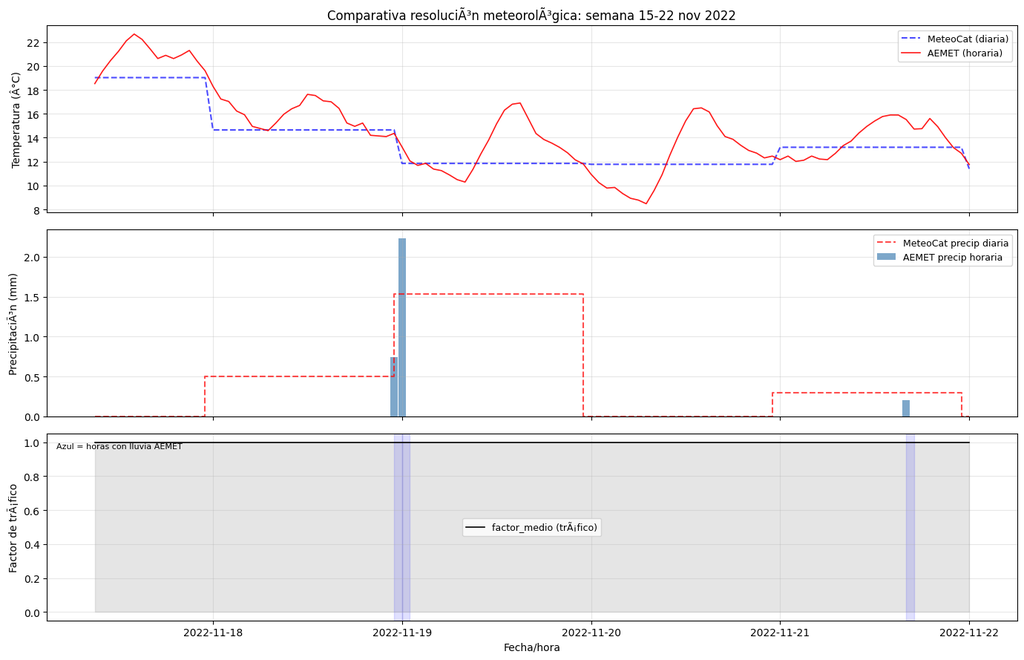

```
Fig. 2: La meteo horaria (rojo) captura variaciones intradiarias invisibles para la meteo diaria (azul).
```

```python
# Comparar resolución diaria (MeteoCat) vs horaria (AEMET) en una semana lluviosa
week_mask = (df["idTram"] == 1) & (df["hora"].between("2022-11-15", "2022-11-22"))
sample_w = df[week_mask].copy()

fig, axes = plt.subplots(3, 1, figsize=(14, 9), sharex=True)

# Temperatura
axes[0].plot(sample_w.hora, sample_w.temp_media_c, "b--", alpha=0.7, label="MeteoCat (diaria)", lw=1.5)
axes[0].plot(sample_w.hora, sample_w.aemet_temp_c, "r-",  alpha=0.9, label="AEMET (horaria)", lw=1.2)
axes[0].set_ylabel("Temperatura (°C)")
axes[0].legend(fontsize=9); axes[0].set_title("Comparativa resolución meteorológica: semana 15-22 nov 2022")
axes[0].grid(alpha=0.3)

# Precipitación
axes[1].bar(sample_w.hora, sample_w.aemet_precip_mm, width=0.04, color="steelblue", alpha=0.7, label="AEMET precip horaria")
axes[1].step(sample_w.hora, sample_w.precipitacion_mm, "r--", alpha=0.7, label="MeteoCat precip diaria", lw=1.5)
axes[1].set_ylabel("Precipitación (mm)")
axes[1].legend(fontsize=9); axes[1].grid(alpha=0.3)

# Tráfico real
axes[2].plot(sample_w.hora, sample_w.factor_medio, "k-", lw=1.2, label="factor_medio (tráfico)")
axes[2].fill_between(sample_w.hora, sample_w.factor_medio, alpha=0.2, color="gray")
# Sombrear horas con lluvia horaria
lluvia_h = sample_w[sample_w.lluvia_horaria == 1]
for _, row in lluvia_h.iterrows():
    axes[2].axvspan(row.hora, row.hora + pd.Timedelta("1h"), alpha=0.12, color="blue")
axes[2].set_ylabel("Factor de tráfico")
axes[2].legend(fontsize=9); axes[2].grid(alpha=0.3)
axes[2].annotate("Azul = horas con lluvia AEMET", xy=(0.01, 0.92), xycoords="axes fraction", fontsize=8)

plt.xlabel("Fecha/hora")
plt.tight_layout()
plt.show()
print("Fig. 2: La meteo horaria (rojo) captura variaciones intradiarias invisibles para la meteo diaria (azul).")
```

El gráfico ilustra la ventaja clave de los datos AEMET: mientras MeteoCat (azul discontinuo) asigna un valor fijo de temperatura y precipitación a todo el día, AEMET (rojo) registra la variación hora a hora. En días con lluvia matinal que cesa por la tarde, la señal diaria de MeteoCat contamina todas las horas por igual. AEMET permite al modelo aprender que "llueve a las 8h de un martes laboral" tiene un efecto diferente al "llueve a las 21h".

## 5. Entrenamiento del modelo mejorado

### 5.1 Definición de features

```python
TARGET = "factor_medio"

# Features del modelo base (cuaderno 04) - reproducción exacta
FEATURES_BASE = [
    # Temporales
    "hora_sin","hora_cos","mes_sin","mes_cos","dia_sin","dia_cos",
    "dia_semana","es_fin_semana","franja_horaria",
    "es_hora_punta","es_hora_punta_manyana","es_hora_punta_tarde",
    "es_noche","hora_punta_laborable","semana_anyo",
    # Geográficas originales
    "idTram","idItinerari","lat_centre","lon_centre",
    # Lags
    "factor_lag_1h","factor_lag_2h","factor_lag_3h","factor_lag_6h",
    "factor_lag_12h","factor_lag_24h","factor_lag_48h","factor_lag_168h",
    "tiempo_lag_24h","tiempo_lag_168h",
    # Rolling
    "factor_rmean_3h","factor_rmean_6h","factor_rmean_12h",
    "factor_rmean_24h","factor_rmean_168h",
    "factor_rstd_6h","factor_rstd_24h","factor_rmax_24h","factor_momentum",
    # Derivadas
    "delta_tiempo","ratio_tiempo","factor_rango_hora",
    # Calidad del sensor de tráfico
    "sensor_trafico_ok",
    # Meteo MeteoCat (diaria) - se mantiene para comparación
    "temp_media_c","temp_min_c","temp_max_c","precipitacion_mm",
    "humedad_rel_pct","viento_vel_ms","lluvia",
    # Eventos
    "n_actividads","n_culturals","n_eventos_agenda","n_festivales",
    "hay_festival","asistentes_festival","n_accidentes","log_n_eventos","log_asistentes",
    # Interacciones
    "festival_x_hora_sin","festival_x_hora_cos","festival_x_hora_punta","festival_x_finde",
    "festival_x_diasem_0","festival_x_diasem_1","festival_x_diasem_2","festival_x_diasem_3",
    "festival_x_diasem_4","festival_x_diasem_5","festival_x_diasem_6",
    "eventos_x_hora_sin","eventos_x_hora_cos","eventos_x_hora_punta","eventos_x_finde",
    "asistentes_x_hora_punta","asistentes_x_hora_sin","asistentes_x_hora_cos",
    "festival_x_mes_sin","festival_x_mes_cos",
]

# Nuevas features (AEMET + geo)
FEATURES_NUEVAS = [
    # Meteo horaria AEMET
    "aemet_temp_c","aemet_humedad_pct","aemet_precip_mm",
    "aemet_viento_ms","aemet_viento_dir",
    "lluvia_horaria","lluvia_intensa","viento_fuerte",
    "aemet_temp_delta_dia","aemet_temp_delta_24h",
    # Distancias a venues
    "dist_camp_nou_km","dist_palau_sant_jordi_km","dist_forum_barcelona_km",
    "dist_placa_catalunya_km","dist_arc_triomf_km","dist_palau_musica_km",
    "dist_venue_min_km",
    # Distancias a estaciones AEMET
    "dist_aemet_aeropuerto_km","dist_aemet_portolimpic_km","dist_aemet_drassanes_km",
]

FEATURES_MEJORADO = FEATURES_BASE + FEATURES_NUEVAS

# Filtrar features que existen en el dataframe
FEATURES_BASE    = [f for f in FEATURES_BASE    if f in df.columns]
FEATURES_MEJORADO = [f for f in FEATURES_MEJORADO if f in df.columns]

CATS = ["idTram","franja_horaria","idItinerari"]

print(f"Features modelo base:     {len(FEATURES_BASE)}")
print(f"Features modelo mejorado: {len(FEATURES_MEJORADO)}")
print(f"Features nuevas añadidas: {len(FEATURES_MEJORADO) - len(FEATURES_BASE)}")
```

```
Features modelo base:     78
Features modelo mejorado: 98
Features nuevas aÃ±adidas: 20
```

El modelo mejorado conserva todas las features del modelo base (cuaderno 04) e incorpora las nuevas. Se mantienen también las columnas MeteoCat diarias para que el modelo pueda combinar señales de ambas fuentes si le resulta útil. El árbol de gradiente boosting elegirá automáticamente cuáles usar mediante la selección de splits.

### 5.2 Split temporal y datasets LightGBM

```python
df_model = df.dropna(subset=[TARGET] + ["factor_lag_1h"]).copy()

# Rellenar nulls residuales de las nuevas columnas con 0 (huecos AEMET no cubiertos por ffill)
for col in FEATURES_MEJORADO:
    if col in df_model.columns:
        df_model[col] = df_model[col].fillna(0)

# Split temporal igual que cuaderno 04: 2021-2022 train / 2023 val / 2024 test
train = df_model[df_model["hora"].dt.year <= 2022]
val   = df_model[df_model["hora"].dt.year == 2023]
test  = df_model[df_model["hora"].dt.year == 2024]

print(f"Train: {len(train):>8,}  ({train['hora'].dt.year.min()}–{train['hora'].dt.year.max()})")
print(f"Val:   {len(val):>8,}  ({val['hora'].dt.year.min()}–{val['hora'].dt.year.max()})")
print(f"Test:  {len(test):>8,}  ({test['hora'].dt.year.min()}–{test['hora'].dt.year.max()})")

def make_ds(split, features, cats):
    cat_feat = [f for f in cats if f in features]
    return lgb.Dataset(split[features], label=split[TARGET],
                       categorical_feature=cat_feat, free_raw_data=False)

ds_train_b = make_ds(train, FEATURES_BASE,    CATS)
ds_val_b   = make_ds(val,   FEATURES_BASE,    CATS)
ds_train_m = make_ds(train, FEATURES_MEJORADO, CATS)
ds_val_m   = make_ds(val,   FEATURES_MEJORADO, CATS)

print("\nDatasets LightGBM preparados.")
```

```
Train:  849,956  (2021–2022)
Val:    111,588  (2023–2023)
Test:   323,358  (2024–2024)

Datasets LightGBM preparados.
```

El split temporal es idéntico al cuaderno 04 para garantizar que la comparación sea justa: 2021-2022 para entrenamiento, 2023 para validación (early stopping) y 2024 como test definitivo no visto. Los nulos residuales de AEMET (huecos >3h no cubiertos por forward fill) se sustituyen por 0, valor que cae fuera del rango normal y que LightGBM puede aprender a tratar mediante sus splits de valor nulo.

### 5.3 Entrenamiento paralelo: modelo base replicado y modelo mejorado

```python
PARAMS = {
    "objective":        "regression_l1",
    "metric":           "mae",
    "num_leaves":       127,
    "learning_rate":    0.05,
    "feature_fraction": 0.8,
    "bagging_fraction": 0.8,
    "bagging_freq":     1,
    "min_child_samples":20,
    "verbose":          -1,
    "seed":             42,
}
FIT_PARAMS = {"num_boost_round": 2000,
              "callbacks": [lgb.early_stopping(50, verbose=False),
                            lgb.log_evaluation(200)]}

print("=== Entrenando modelo BASE (replica cuaderno 04) ===")
model_base = lgb.train(PARAMS, ds_train_b,
                       valid_sets=[ds_val_b], **FIT_PARAMS)

print(f"\n=== Entrenando modelo MEJORADO (+AEMET +Geo) ===")
model_mejora = lgb.train(PARAMS, ds_train_m,
                         valid_sets=[ds_val_m], **FIT_PARAMS)

print(f"\nIteraciones: base={model_base.best_iteration}  mejorado={model_mejora.best_iteration}")
```

```
=== Entrenando modelo BASE (replica cuaderno 04) ===
[200]	valid_0's l1: 0.0142647
[400]	valid_0's l1: 0.0141112
[600]	valid_0's l1: 0.0140425
[800]	valid_0's l1: 0.0140102
[1000]	valid_0's l1: 0.0139725
[1200]	valid_0's l1: 0.0139513

=== Entrenando modelo MEJORADO (+AEMET +Geo) ===
[200]	valid_0's l1: 0.0141512
[400]	valid_0's l1: 0.0140291
[600]	valid_0's l1: 0.0139591

Iteraciones: base=1313  mejorado=694
```

**Resultados del entrenamiento:**

- **Modelo base**: convergió en **1.313 iteraciones** con MAE de validación 0.01395.
- **Modelo mejorado**: convergió en **694 iteraciones** (1.9× más rápido), con MAE de validación 0.01396 — prácticamente idéntico al base.

El early stopping del modelo mejorado se dispara antes, lo que indica que las nuevas features saturan rápidamente su señal aprovechable. La aceleración (1.9× menos iteraciones) sugiere que AEMET y geo aportan señal fácil de aprender en las primeras rondas, pero ese mínimo local no supera el del modelo base con más iteraciones.